# Predicting the Authorship of Poetry Snippets

Nick Dieffenbacher-Krall  
April 29, 2019

### Project Goals

- Determine the author of a poem using only data from that poem
- A classification problem
- Test data includes only the text of the poem

### Applications

- Determining authorship
- Classifying unknown words
- Comparing an author's canon

[figure not shown]

### Obtaining Data

- Poems were sourced from Project Gutenberg
- 1774 peoms from 7 19th century poets
- Parsed from books via Python script

```
                           Book          Author
1 Poems: Three Series, Complete Emily Dickinson
                                                                                                                                                                                              Poem
1 That never wrote to me, --\nThe simple news that Nature told,\nWith tender majesty.\nHer message is committed\nTo hands I cannot see;\nFor love of her, sweet countrymen,\nJudge tenderly of me!
```

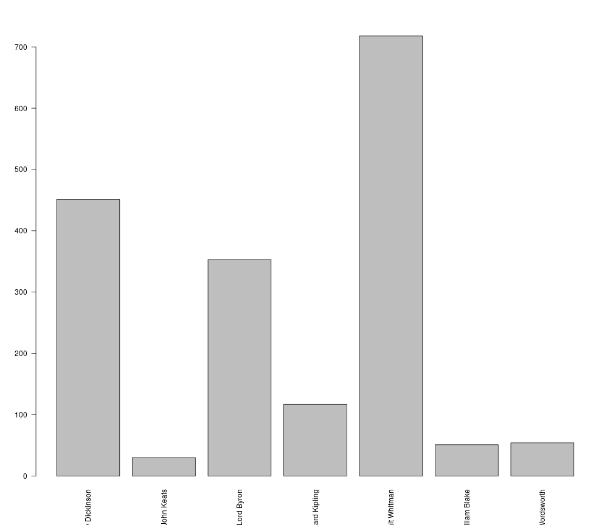

### Creating Variables

- In order to do any classification, we need to create variables from the poem text
- Some easy initial variables are
  - Words per line
  - Lines per stanza
- Not yet very useful

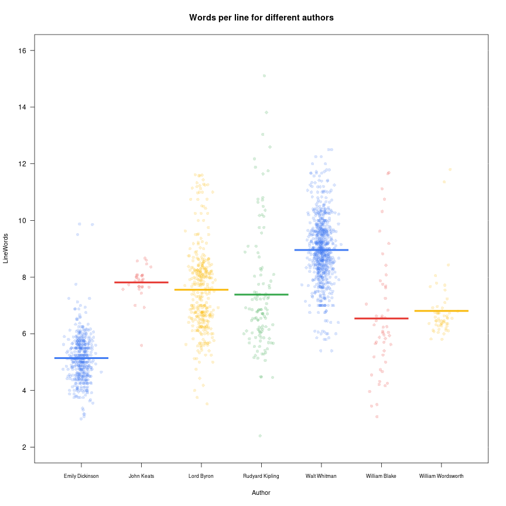

### Natural Language Processing

“Much madness is divinest sense  
To a discerning eye;  
Much sense the starkest madness.  
'T is the majority  
In this, as all, prevails.  
Assent, and you are sane;  
Demur, – you're straightway dangerous,  
And handled with a chain.”  
- Emily Dickinson

- Analysis performed by word
- Data is cleaned to make analysis easier

“much madness divinest sense discerning eye much sense starkest madness t majority prevails assent sane demur youre straightway dangerous handled chain”

- Whitespace removed
- Stop words removed
- Punctuation removed
- Experimenting with stemming words

### Wordclouds

We can visualize the differences in word use between poet with a word cloud.

Emily Dickinson

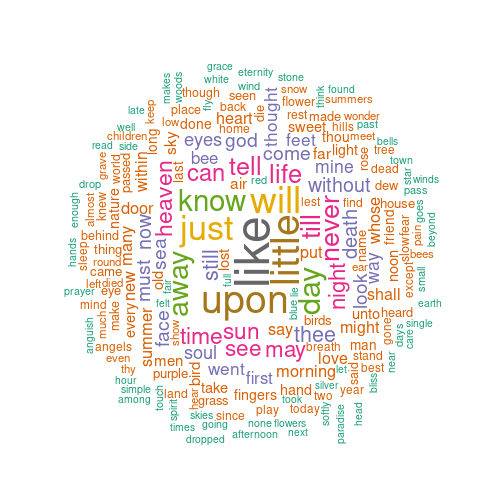

William Blake

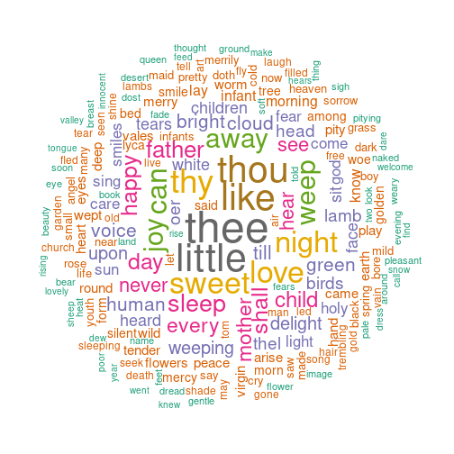

### Sentiment Analysis

- A common way of creating data from natural langauge
- Using the AFINN sentiment lexicon

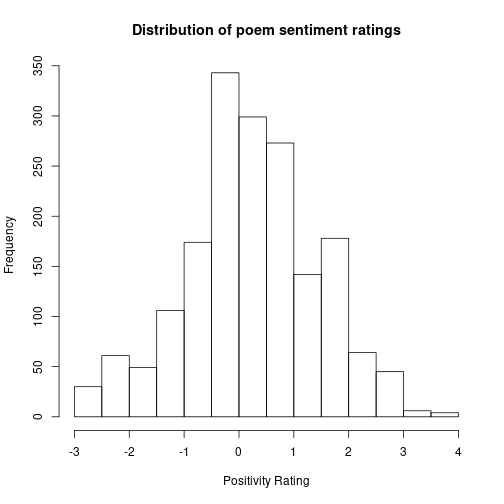

### Comparision of Sentiments

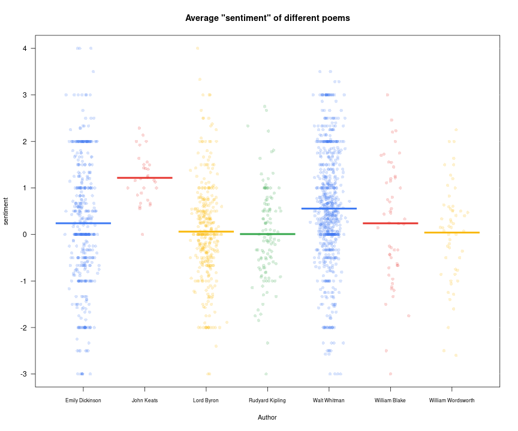

### Can we make predictions?

- We may have enough variables to make successful predictions
- Use test and train sets to evaluate models

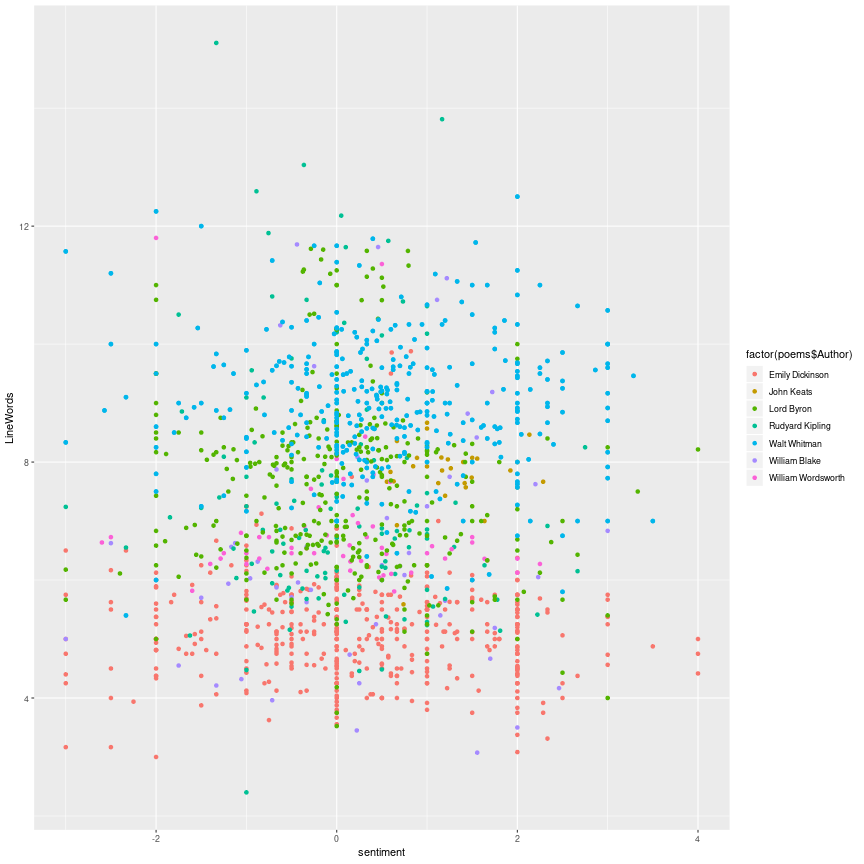

### Using SVM to classify author

- Using a linear kernel, two dimensions
  - Words per line
  - Sentiment
- Cost parameter evaluated by 5 fold CV
- The model gives a successful classification rate of 0.6734234 on the test data.

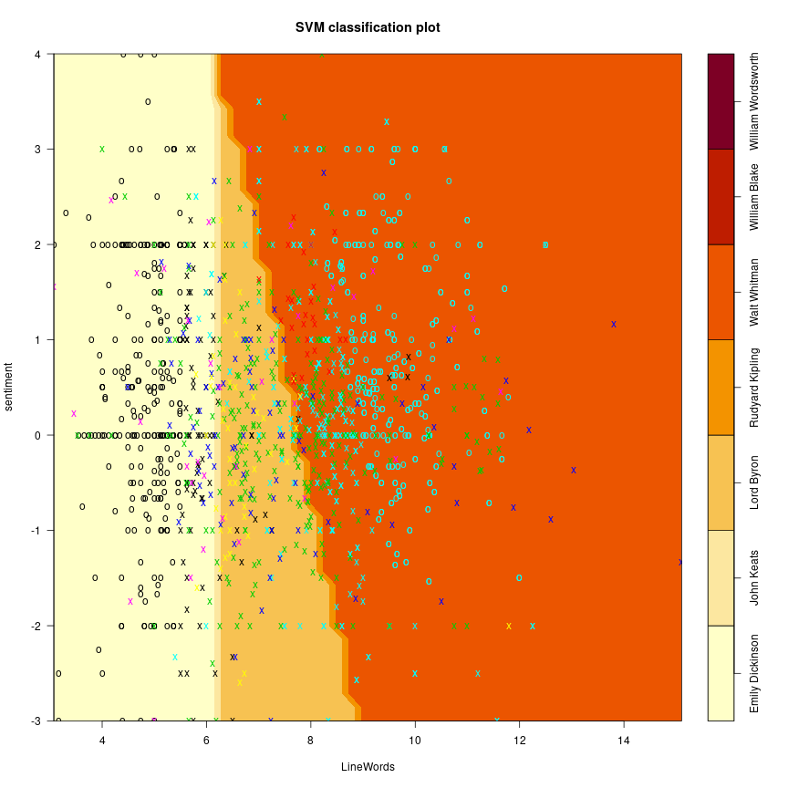

### Further work

- More complex sentiment analysis
- Discrete variables based on word usage
- Create model using `xgboost`, and others
- Latent Dirichlet Allocation (the other LDA)